# Name : **Bhavin Bhatt**

# Demystifying San Francisco Salaries and Compensation Benefits

## Balancing Cost of Living with SanFrancisco Pay Scales

[figure not shown]

```r
df1 <- read.csv("/content/employee-compensation.csv")
```

## **1) Objective of the Proposed Research:**

- The primary objective of the research is to comprehensively analyze the key factors influencing the cost of living in the city, with a specific focus on income. The dataset consists of data related to company, departments, salaries and benefits which gives us a glimpse about the job scenario in San Francisco. With the help of this thorough analysis, the research aims to provide valuable insights into the complex economic dynamics that shape the lives of San Francisco residents.
- Firstly, the research seeks to provide a clear and data-driven understanding of income trends in San Francisco. This includes examining median household incomes, income disparities, and the influence of major employment sectors on income levels. This thorough examination will allow readers to grasp the economic diversity within the city and comprehend the financial challenges faced by various segments of the population.
- Secondly, the research aims to uncover how fifferent jobs types correlate with retirement, health,dental and other benefits that affect the essential living expenses in San Francisco. Additionally, the report will delve into the relationship between the departmenOrganization Group, department, Job Family and their respective compensation benefits it offers to its employees inorder to secure their future.
- Lastly, the objective of this research is to equip San Francisco Chronicle newspaper with actionable insights into the income dynamics of San Francisco. By presenting a comprehensive and data-driven view of income-related issues, the research serves as a vital tool for informed decision-making for the readers of the San Francisco Chronicle.

# **2) Data Exploration.**

We will explore different parts of data by doing Exploratory data anlysis of our dataframe DF

```r
# Checking insights on the data
# importing the necessary libraries for our analysis
library(readr)
library(tidyverse)
library(dplyr)
library(readr)
```

2.1) Displaying first 10 rows of the dataframe

```r
head(df1,10)
```

A data.frame: 10 × 22

|  | Organization.Group.Code <int> | Job.Family.Code <chr> | Job.Code <chr> | Year.Type <chr> | Year <int> | Organization.Group <chr> | Department.Code <chr> | Department <chr> | Union.Code <int> | Union <chr> | ⋯ | Employee.Identifier <int> | Salaries <dbl> | Overtime <dbl> | Other.Salaries <dbl> | Total.Salary <dbl> | Retirement <dbl> | Health.and.Dental <dbl> | Other.Benefits <dbl> | Total.Benefits <dbl> | Total.Compensation <dbl> |
| --- | --- | --- | --- | --- | --- | --- | --- | --- | --- | --- | --- | --- | --- | --- | --- | --- | --- | --- | --- | --- | --- |
| 1 | 1 | 1000 | 1021 | Calendar | 2013 | Public Protection | ADP | ADP Adult Probation | 21 | Prof & Tech Engineers - Miscellaneous, Local 21 | ⋯ | 37730 | 57534.65 | 0 | 0.00 | 57534.65 | 11253.16 | 11961.34 | 4532.63 | 27747.13 | 85281.78 |
| 2 | 1 | 1000 | 1023 | Calendar | 2013 | Public Protection | ADP | ADP Adult Probation | 21 | Prof & Tech Engineers - Miscellaneous, Local 21 | ⋯ | 26574 | 57678.50 | 0 | 0.00 | 57678.50 | 10284.88 | 7176.80 | 4755.14 | 22216.82 | 79895.32 |
| 3 | 1 | 1000 | 1031 | Calendar | 2013 | Public Protection | ADP | ADP Adult Probation | 21 | Prof & Tech Engineers - Miscellaneous, Local 21 | ⋯ | 8148 | 63532.93 | 0 | 0.00 | 63532.93 | 12495.83 | 12918.24 | 4702.71 | 30116.78 | 93649.71 |
| 4 | 1 | 1000 | 1054 | Calendar | 2013 | Public Protection | ADP | ADP Adult Probation | 21 | Prof & Tech Engineers - Miscellaneous, Local 21 | ⋯ | 27436 | 101274.51 | 0 | -7058.59 | 94215.92 | 19644.45 | 12918.24 | 7458.76 | 40021.45 | 134237.37 |
| 5 | 1 | 1000 | 1062 | Calendar | 2013 | Public Protection | ADP | ADP Adult Probation | 21 | Prof & Tech Engineers - Miscellaneous, Local 21 | ⋯ | 37730 | 5084.00 | 0 | 0.00 | 5084.00 | 1083.90 | 956.91 | 387.50 | 2428.31 | 7512.31 |
| 6 | 1 | 1000 | 1064 | Calendar | 2013 | Public Protection | ADP | ADP Adult Probation | 21 | Prof & Tech Engineers - Miscellaneous, Local 21 | ⋯ | 36223 | 34456.00 | 0 | 0.00 | 34456.00 | 7346.00 | 3827.63 | 2579.95 | 13753.58 | 48209.58 |
| 7 | 1 | 1000 | 1070 | Calendar | 2013 | Public Protection | ADP | ADP Adult Probation | 21 | Prof & Tech Engineers - Miscellaneous, Local 21 | ⋯ | 51426 | 139889.00 | 0 | 0.00 | 139889.00 | 26799.23 | 12918.24 | 9791.54 | 49509.01 | 189398.01 |
| 8 | 1 | 1000 | 1094 | Calendar | 2013 | Public Protection | ADP | ADP Adult Probation | 21 | Prof & Tech Engineers - Miscellaneous, Local 21 | ⋯ | 26574 | 46572.00 | 0 | 0.00 | 46572.00 | 9929.16 | 5741.44 | 3822.28 | 19492.88 | 66064.88 |
| 9 | 1 | 1200 | 1232 | Calendar | 2013 | Public Protection | ADP | ADP Adult Probation | 21 | Prof & Tech Engineers - Miscellaneous, Local 21 | ⋯ | 37983 | 84681.53 | 0 | 0.00 | 84681.53 | 16661.84 | 12918.24 | 6838.44 | 36418.52 | 121100.05 |
| 10 | 1 | 1600 | 1654 | Calendar | 2013 | Public Protection | ADP | ADP Adult Probation | 21 | Prof & Tech Engineers - Miscellaneous, Local 21 | ⋯ | 16858 | 10611.01 | 0 | 0.00 | 10611.01 | 1879.20 | 1435.36 | 827.09 | 4141.65 | 14752.66 |

2.2) Getting a list of the column names in the Dataframe

```r
colnames(df1)
```

1. 'Organization.Group.Code'

2. 'Job.Family.Code'

3. 'Job.Code'

4. 'Year.Type'

5. 'Year'

6. 'Organization.Group'

7. 'Department.Code'

8. 'Department'

9. 'Union.Code'

10. 'Union'

11. 'Job.Family'

12. 'Job'

13. 'Employee.Identifier'

14. 'Salaries'

15. 'Overtime'

16. 'Other.Salaries'

17. 'Total.Salary'

18. 'Retirement'

19. 'Health.and.Dental'

20. 'Other.Benefits'

21. 'Total.Benefits'

22. 'Total.Compensation'

2.3) Getting the total numberof rows & columns in our dataframe

```r
cat("Number of rows: ", nrow(df1), "\n")
cat("Number of columns: ", ncol(df1), "\n")
```

```
Number of rows:  683277
Number of columns:  22
```

2.4) Getting the column types in a dataframe

```r
sapply(df1, typeof)
```

**Organization.Group.Code**

'integer'

**Job.Family.Code**

'character'

**Job.Code**

'character'

**Year.Type**

'character'

**Year**

'integer'

**Organization.Group**

'character'

**Department.Code**

'character'

**Department**

'character'

**Union.Code**

'integer'

**Union**

'character'

**Job.Family**

'character'

**Job**

'character'

**Employee.Identifier**

'integer'

**Salaries**

'double'

**Overtime**

'double'

**Other.Salaries**

'double'

**Total.Salary**

'double'

**Retirement**

'double'

**Health.and.Dental**

'double'

**Other.Benefits**

'double'

**Total.Benefits**

'double'

**Total.Compensation**

'double'

2.5) Getting the mean and median for Total salaries columns

```r
summary(df1$Total.Salary,na.rm=TRUE)
```

```
   Min. 1st Qu.  Median    Mean 3rd Qu.    Max.
 -68772   31676   74870   78571  112666  658868
```

# **3) Subsets of Data**

The following columns would give us valuable insights about the data such as Organization.group, Year.type, Year, ,Department, Job, Total.Salary, Retirement, Total.Benefits which will help in analyzing the job market conditions in San Francisco.

```r
head(df1,4)
```

A data.frame: 4 × 22

|  | Organization.Group.Code <int> | Job.Family.Code <chr> | Job.Code <chr> | Year.Type <chr> | Year <int> | Organization.Group <chr> | Department.Code <chr> | Department <chr> | Union.Code <int> | Union <chr> | ⋯ | Employee.Identifier <int> | Salaries <dbl> | Overtime <dbl> | Other.Salaries <dbl> | Total.Salary <dbl> | Retirement <dbl> | Health.and.Dental <dbl> | Other.Benefits <dbl> | Total.Benefits <dbl> | Total.Compensation <dbl> |
| --- | --- | --- | --- | --- | --- | --- | --- | --- | --- | --- | --- | --- | --- | --- | --- | --- | --- | --- | --- | --- | --- |
| 1 | 1 | 1000 | 1021 | Calendar | 2013 | Public Protection | ADP | ADP Adult Probation | 21 | Prof & Tech Engineers - Miscellaneous, Local 21 | ⋯ | 37730 | 57534.65 | 0 | 0.00 | 57534.65 | 11253.16 | 11961.34 | 4532.63 | 27747.13 | 85281.78 |
| 2 | 1 | 1000 | 1023 | Calendar | 2013 | Public Protection | ADP | ADP Adult Probation | 21 | Prof & Tech Engineers - Miscellaneous, Local 21 | ⋯ | 26574 | 57678.50 | 0 | 0.00 | 57678.50 | 10284.88 | 7176.80 | 4755.14 | 22216.82 | 79895.32 |
| 3 | 1 | 1000 | 1031 | Calendar | 2013 | Public Protection | ADP | ADP Adult Probation | 21 | Prof & Tech Engineers - Miscellaneous, Local 21 | ⋯ | 8148 | 63532.93 | 0 | 0.00 | 63532.93 | 12495.83 | 12918.24 | 4702.71 | 30116.78 | 93649.71 |
| 4 | 1 | 1000 | 1054 | Calendar | 2013 | Public Protection | ADP | ADP Adult Probation | 21 | Prof & Tech Engineers - Miscellaneous, Local 21 | ⋯ | 27436 | 101274.51 | 0 | -7058.59 | 94215.92 | 19644.45 | 12918.24 | 7458.76 | 40021.45 | 134237.37 |

- Organization.Group - This column gives us details about the organisation group as whole under which there are various departments.
- Year - This column provides us details about the year and used in filtering data from the type of year. Its range is from 2013 to 2020.
- Year.Type - This column type provides us with the two types of year which are Fiscal and Calendar. Using 2015 as an example, Fiscal Year 2015 covers the period from July 2014 to June 2015 and Calendar Year 2015 covers the period from January 2015 to December 2015. We will consider Fiscal year for our analysis as hiring, financial and all other statistics for a company are based on fiscal year.
- Department - This column provides us details about various departments that fall under the organization umbrella. We would use this column to predict which department offers higher and lower salaries.
- Job - This column provides us with detailed information about the designation of the employee. This can also provide us with the salary range within a particular job role for a fresher and experienced employee and their growth potential.
- Total.Salary - This column consists of sum of Salary + Overtime + Other benefits from the main dataframe. We weill use this as our primary data to predict various patterns in paygrades among companies.
- Retirement - This column describes city contributions to employee retirement plans. We will use this column data to describe which job has more security as compared to others.
- Total Benefits - This column is Retirement + Health&Dental Benefits + Other Benefits. It describes the total benefits that a company offers to an employee interms of health, retirement and other benefits.

```r
#Subset 1 for Organisation providing highest employment
#Counting which Organization group provides maximum employment
Employment <- df1[c('Organization.Group', 'Year', 'Year.Type')]
Employment <- Employment[Employment$Year.Type == 'Fiscal',]
Employment_stats <- Employment%>%group_by(Organization.Group, Year)%>%summarise(Total_employees = n())%>%ungroup()
head(Employment_stats,5)
#tail(Employment_stats, 10)
dim(Employment_stats)
```

A tibble: 5 × 3

| Organization.Group <chr> | Year <int> | Total_employees <int> |
| --- | --- | --- |
| Community Health | 2013 | 8864 |
| Community Health | 2014 | 8960 |
| Community Health | 2015 | 9148 |
| Community Health | 2016 | 9373 |
| Community Health | 2017 | 19131 |

1. 53

2. 3

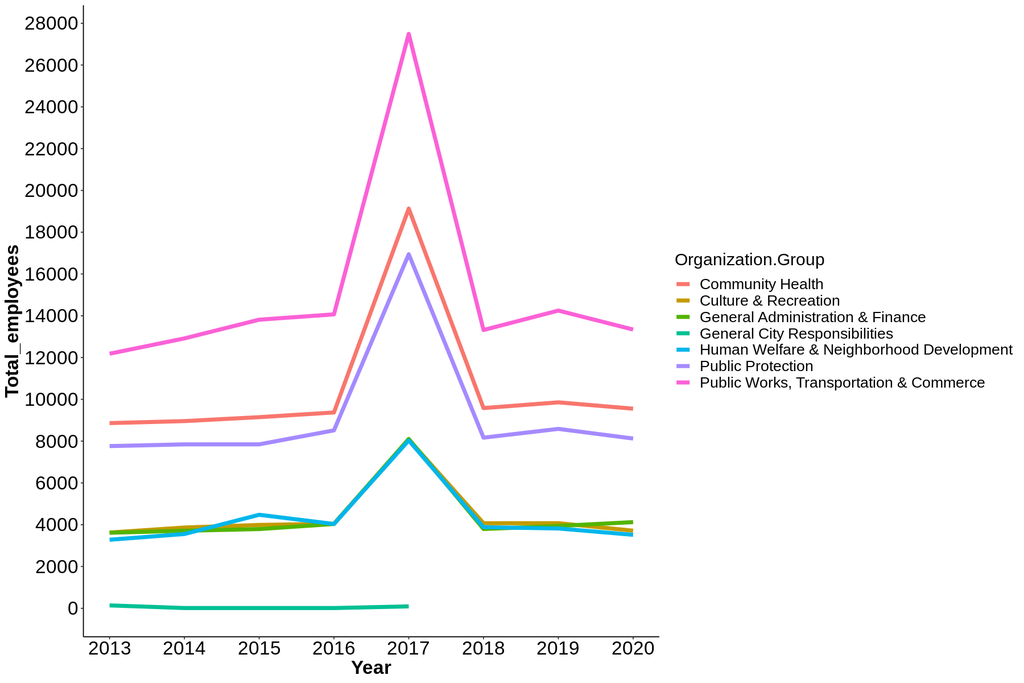

```r
#Plotting Organisations providing highest employment.

library(ggplot2)
library(dplyr)
library(tidyr)

options(
  repr.plot.width = 15,    # Set the desired width (in inches)
  repr.plot.height = 10    # Set the desired height (in inches)
)

ggplot(Employment_stats, aes(x = Year, y = Total_employees, color = Organization.Group)) +
  geom_line(lwd = 2) +
  theme_classic() +
  theme(
    axis.title = element_text(size = 20, face = 'bold'),
    axis.text = element_text(size = 20, color = 'black'),
    legend.text = element_text(size = 16),   # Increase legend text size
    legend.title = element_text(size = 18)
  ) +
  scale_x_continuous(
    breaks = seq(2013, 2020, by = 1),   # Set tick marks for years 2013 to 2020
    labels = seq(2013, 2020, by = 1)    # Set labels for the corresponding years
  ) +
  scale_y_continuous(
    breaks = seq(0, 50000, by = 2000),   # Set y-axis tick marks at 2000 intervals
    labels = seq(0, 50000, by = 2000)    # Set y-axis labels at 2000 intervals
  )
```

- It can be observed from the above subset that Public Works, Transportation & Commerce department offers highest employment compared to other departments whereas the General city responsibilitites provides lowest employment.

```r
#Selecting Subset 2 for jobs with highest salaries
Highest_Salary <- df1[c('Organization.Group','Year','Year.Type','Job','Total.Salary')]

#Selecting Fiscal year
Highest_Salary<- Highest_Salary[Highest_Salary$Year.Type == 'Fiscal',]

Highest_Salary <- Highest_Salary %>%group_by(Job, Year, Organization.Group)%>%arrange(desc(Total.Salary))

#Selecting Year 2020 which is the last updated data for highest salaries
Highest_Salary <- Highest_Salary[Highest_Salary$Year == '2020',]%>%head(n = 10)

head(Highest_Salary)
dim(Highest_Salary)
```

A grouped_df: 6 × 5

| Organization.Group <chr> | Year <int> | Year.Type <chr> | Job <chr> | Total.Salary <dbl> |
| --- | --- | --- | --- | --- |
| General Administration & Finance | 2020 | Fiscal | Chief Investment Officer | 584297.6 |
| General Administration & Finance | 2020 | Fiscal | Managing Director | 488641.2 |
| General Administration & Finance | 2020 | Fiscal | Managing Director | 488218.4 |
| Public Protection | 2020 | Fiscal | Senior Deputy Sheriff | 473095.0 |
| Community Health | 2020 | Fiscal | Physician Administrator, DPH | 465612.0 |
| General Administration & Finance | 2020 | Fiscal | Asst Med Examiner | 465501.5 |

1. 10

2. 5

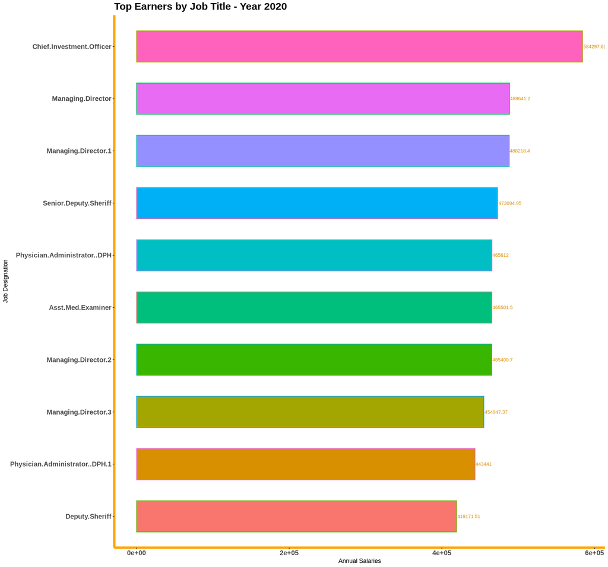

```r
#Plotting top 10 earners from the year 2020

#Providing unique labels for duplicate values
if (any(duplicated(Highest_Salary$Job))) {
  Highest_Salary$Job <- make.names(Highest_Salary$Job, unique = TRUE)
}

Highest_Salary$Job <- factor(Highest_Salary$Job,levels = Highest_Salary$Job[order(Highest_Salary$Total.Salary)])

# Reorder the "Job" factor based on "Total.Salary" in descending order
#Highest_Salary$Job <- reorder(Highest_Salary$Job, -Highest_Salary$Total.Salary)

ggplot(Highest_Salary, aes(Job, Total.Salary, color = Job, fill = Job)) +
  geom_bar(position = "stack", width = 0.6, stat = "identity") +
  coord_flip() +
  geom_text(aes(label = Total.Salary, hjust = -0.03, colour = "black"), size = 3) +

  theme(axis.line = element_line(color = "orange", size = 2)) +
  theme(panel.background = element_blank()) +
  scale_x_discrete() +
  xlab("Job Designation") + ylab("Annual Salaries") +
  theme(legend.position = "none", axis.text = element_text(size = 12, face = "bold"),
        plot.title = element_text(size = 18, face = "bold")) +
  ggtitle("Top Earners by Job Title - Year 2020")

#Increasing the plot size
options(
  repr.plot.width = 12,
  repr.plot.height = 8
)
```

From Subset 2 we can observe top 10 highest earners for the year 2020. We selected 2020 since it gives us the latest market scenario for highest earners as per our dataset. The top 10 earners mostly comprises of Organization groups such as General Administration & Finance as well as Public Protection group. The top earner for the year 2020 is Chief Investment Officer with an annual pay of $5,84,297.6 without considering other benefits.

```r
#Selecting Subset 3 for jobs with lowest salaries
Lowest_Salary <- df1[c('Organization.Group','Year','Year.Type','Job.Family','Job','Salaries')]

#Selecting Fiscal year
Lowest_Salary <- Lowest_Salary[Lowest_Salary$Year.Type == 'Fiscal',]

#Selecting Year 2020 which is the last updated data for highest salaries
#Lowest_Salary <- Lowest_Salary[Lowest_Salary$Year == '2020',]

Lowest_Salary <- Lowest_Salary %>%group_by(Job)%>%arrange(Salaries)%>%filter(Salaries > 100)%>%head(n=30)
head(Lowest_Salary,3)
```

A grouped_df: 3 × 6

| Organization.Group <chr> | Year <int> | Year.Type <chr> | Job.Family <chr> | Job <chr> | Salaries <dbl> |
| --- | --- | --- | --- | --- | --- |
| Culture & Recreation | 2017 | Fiscal | Library | Library Page | 100.11 |
| Culture & Recreation | 2017 | Fiscal | Library | Library Page | 100.11 |
| Public Works, Transportation & Commerce | 2016 | Fiscal | Sub-Professional Engineering | Stdntdsgntrain1, Arch/Eng/Plng | 100.35 |

It was observed from the above dataset that the lowest earner category mainly belongs to

```r
#Subset 4 - Finding the lowest actual benefit job group
Benefits <- df1[c('Organization.Group','Year','Year.Type','Job','Job.Family','Salaries', 'Retirement','Health.and.Dental','Other.Benefits')]

#Selecting the Fiscal Year type

Benefits <- Benefits[Benefits$Year.Type == 'Fiscal',]

Benefits$Retirement <- as.numeric(Benefits$Retirement)
Benefits$Health.and.Dental <- as.numeric(Benefits$Health.and.Dental)
Benefits$Other.Benefits <- as.numeric(Benefits$Other.Benefits)

#Adding Retirement, Health&Dental and Other Benefits and creating a new column named Actual Benefits
Benefits$Actual.Benefits <- Benefits$Retirement + Benefits$Health.and.Dental + Benefits$Other.Benefits

Benefits <- Benefits%>%group_by(Job)%>%arrange(Actual.Benefits)
head(Benefits, 5)
#Considering only positive values
Benefits <- Benefits%>%group_by(Job)%>%arrange(Actual.Benefits)%>%filter(Actual.Benefits > 0)

#Benefits <- Benefits%>%arrange(desc(Year))
head(Benefits,5)
```

A grouped_df: 5 × 10

| Organization.Group <chr> | Year <int> | Year.Type <chr> | Job <chr> | Job.Family <chr> | Salaries <dbl> | Retirement <dbl> | Health.and.Dental <dbl> | Other.Benefits <dbl> | Actual.Benefits <dbl> |
| --- | --- | --- | --- | --- | --- | --- | --- | --- | --- |
| Community Health | 2014 | Fiscal | Nurse Practitioner | Nursing | 16493.99 | -28723.19 | 0 | 8908.75 | -19814.44 |
| Community Health | 2014 | Fiscal | Special Nurse | Nursing | 36520.06 | -28016.08 | 0 | 10319.82 | -17696.26 |
| Community Health | 2018 | Fiscal | Special Nurse | Nursing | 137190.70 | -26670.15 | 0 | 10349.78 | -16320.37 |
| Community Health | 2018 | Fiscal | Special Nurse | Nursing | 143490.49 | -24818.10 | 0 | 10051.63 | -14766.47 |
| Community Health | 2013 | Fiscal | Nurse Practitioner | Nursing | 13819.93 | -21302.02 | 0 | 7290.09 | -14011.93 |

A grouped_df: 5 × 10

| Organization.Group <chr> | Year <int> | Year.Type <chr> | Job <chr> | Job.Family <chr> | Salaries <dbl> | Retirement <dbl> | Health.and.Dental <dbl> | Other.Benefits <dbl> | Actual.Benefits <dbl> |
| --- | --- | --- | --- | --- | --- | --- | --- | --- | --- |
| Human Welfare & Neighborhood Development | 2017 | Fiscal | Program Support Analyst | Human Services | 0.00 | 0.03 | 0 | -0.02 | 0.01 |
| Community Health | 2014 | Fiscal | Special Nurse | Nursing | 2069.55 | 0.00 | 0 | 0.01 | 0.01 |
| Community Health | 2014 | Fiscal | Special Nurse | Nursing | 1698.90 | 0.00 | 0 | 0.01 | 0.01 |
| Culture & Recreation | 2014 | Fiscal | Pool Lifeguard | Recreation | 17.26 | 0.00 | 0 | 0.01 | 0.01 |
| Community Health | 2015 | Fiscal | Special Nurse | Nursing | 1076.40 | 0.00 | 0 | 0.01 | 0.01 |

It can be observed that the above subset that the Actual benefits are less and negative in some cases for the Job.Family type Nursing and Organisation Group being Community Health. This means there is very less job security in Nursing as a profession.

[output not shown]

A tibble: 6 × 5

| Organization.Group <chr> | Union <chr> | Year <int> | Job.Family <chr> | Total_Union <int> |
| --- | --- | --- | --- | --- |
| Community Health | SEIU, Local 1021, RN | 2020 | Nursing | 3400 |
| Public Works, Transportation & Commerce | TWU, Local 250-A, TransitOpr | 2020 | Street Transit | 2741 |
| Public Protection | POA | 2020 | Police Services | 2415 |
| Public Protection | Firefighters,Local 798, Unit 1 | 2020 | Fire Services | 1763 |
| Human Welfare & Neighborhood Development | SEIU, Local 1021, Misc | 2020 | Human Services | 1457 |
| Culture & Recreation | SEIU, Local 1021, Misc | 2020 | Recreation | 1202 |

1. 10

2. 5

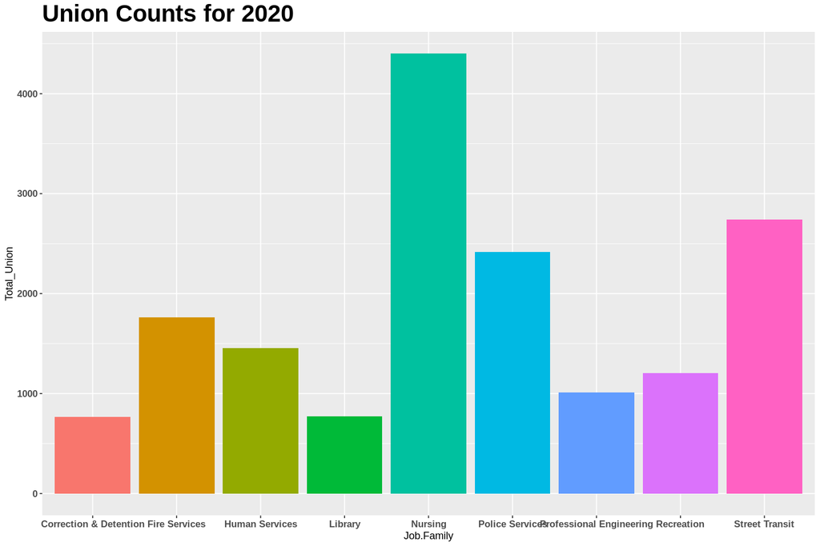

```r
#Subset 5 <- Counting the number of unions with department types and Organisation types

Unions <- df1[c('Organization.Group','Year','Year.Type','Union', 'Job.Family')]
#Selecting the Fiscal Year type

Unions <- Unions[Unions$Year.Type == 'Fiscal',]
Union_count <- Unions[Unions$Year == '2020',]

Union_count <- Union_count%>%group_by(Organization.Group,Union, Year, Job.Family)%>%summarise(Total_Union = n())%>% arrange(desc(Total_Union))%>%head(n=10)%>%ungroup()
#Union_count <- Union_count %>% arrange(desc(Total_Union))%>%head(n=10)
head(Union_count)
dim(Union_count)
#Plotting Unions
ggplot(Union_count, aes(x = Job.Family, y = Total_Union, fill = Job.Family)) +
  geom_bar(stat = "identity") +
  labs(title = "Job.Family", x = "Job.Family", y = "Total_Union") +
  theme(legend.position = "none",
                     axis.text = element_text(size = 10,face="bold"),
        plot.title = element_text(size=25,face = "bold")) +
  ggtitle("Union Counts for 2020")
options(
  repr.plot.width = 15,
  repr.plot.height = 14
)
```

The data for Total union counts is taken for the Year 2020. It is observed that the total unions for the Job. Family type for Nursings are highest followed by Street Transit and Police Services.

# 4) Single Vector

Creating a vector of job titles with lowest compensation.

```r
# Calculating the Lowest Average compensation for top 5 jobs
Lowest_Compensation <- df1[c('Year','Year.Type','Job','Job.Family','Total.Compensation')]

#Filtering df1 dataframe for the Year type Fiscal and Year 2020
Lowest_Compensation <- Lowest_Compensation[Lowest_Compensation$Year.Type %in% c('Fiscal'),]
Lowest_Compensation <- Lowest_Compensation[Lowest_Compensation$Year %in% c('2020'),]

Lowest_Compensation$Total.Compensation <- as.numeric(Lowest_Compensation$Total.Compensation)

#Now calculate the lowest compensation averaging Total Compensation

#Removing Job titles with unknown Job Family
Lowest_Compensation_Average <- Lowest_Compensation_Average[Lowest_Compensation_Average$Job.Family != 'Untitled', ]
Lowest_Compensation_Average <- Lowest_Compensation_Average[Lowest_Compensation_Average$Job.Family != 'Unassigned', ]

#Filtering positive values
Lowest_Compensation_Average <- Lowest_Compensation_Average %>% group_by(Job) %>% arrange(Total.Compensation) %>% filter(Total.Compensation > 0)%>%head(n=5)%>%ungroup()
head(Lowest_Compensation_Average)

# Assigning the dataframe to the vectors
vector.Lowest_Compensation_Average <- c(Lowest_Compensation_Average$Job)

#Displaying Job titles
cat(vector.Lowest_Compensation_Average, sep = "\n")
```

A tibble: 5 × 5

[output not shown]

```
Diagnostic Imaging Tech IV
Pre-Appren Automotive Mechanic
Barber
Camp Assistant
Testing Technician
```

The vector above denotes job titles with lowest total compensation for the Year 2020.

# 5) 5 different Lists

```r
#List 1 <- Public Works Transportation and Commerce offers highest employment as per the Subset 1
Employment_stats %>% arrange(desc(Total_employees))
Employment_stats1 <- Employment_stats[Employment_stats$Year == '2020',] %>% head(n=5)

#Converting dataframe into list 1
Employment_stats_vector <- Employment_stats1$Organization.Group

# Convert the vector to a list
Employment_stats_list <- as.list(Employment_stats_vector)

cat("List 1 - List 1 represents the top five organization groups with the highest employment levels in the year 2020,
 spanning various sectors like healthcare, culture, administration, welfare, and public protection within the dataset.")
(Employment_stats_list)

#List 2 - Job titles with lowest salaries
Lowest_Salary_vector <- Lowest_Salary$Job
Lowest_Salary_list <- as.list(Lowest_Salary_vector)
Lowest_Salary_list <- unique(Lowest_Salary_list)
cat("List 2 - List 2 comprises the ten job titles associated with the lowest salaries, covering various positions
such as library pages, student design trainees, public service aides, and more, indicating roles with comparatively
 lower compensation levels in the dataset.")
Lowest_Salary_list

#List 3 - List with jobs having lowest actual benefits
Benefits_vector <- Benefits$Job
Benefits_list <- as.list(Benefits_vector)
Benefits_list <- unique(Benefits_list)

cat("List 3 - It identifies five job titles characterized by the least generous benefit packages, encompassing roles
such as program support analysts, special nurses, pool lifeguards, junior administrative analysts, and camp assistants,
indicating positions with relatively limited benefits within the dataset.")
head(Benefits_list,5)

#List 4 - Job Family with highest union
Union_count_vector <- Union_count$Job.Family
Union_count_list <- as.list(Union_count_vector)

cat("List 4 - List 4 presents the top five Job.Family types with the highest number of unionized positions for the year 2020,
including categories like nursing, street transit, police services, fire services, and human services, signifying the prevalence
of unions within these specific job families during that year.")
head(Union_count_list, 5)

#List 5 - Finding Lowest Average Total compensation
Lowest_Compensation_Average_list <- as.list(vector.Lowest_Compensation_Average)
cat("List 5 features the top five job titles characterized by the lowest average total compensation over the span of 2013 to 2020.
These roles include diagnostic imaging technicians, pre-apprentice automotive mechanics, barbers, camp assistants, and testing technicians,
indicating positions with comparatively lower overall compensation within the dataset during this period.")
head(Lowest_Compensation_Average_list, 5)
```

A tibble: 5 × 3

[output not shown]

[output not shown]

1. 'Community Health'

2. 'Culture & Recreation'

3. 'General Administration & Finance'

4. 'Human Welfare & Neighborhood Development'

5. 'Public Protection'

[output not shown]

1. 'Library Page'

2. 'Stdntdsgntrain1, Arch/Eng/Plng'

3. 'Public Svc Aide-Public Works'

4. 'Special Nurse'

5. 'Testing Technician'

6. 'Junior Clerk'

7. 'Recreation Leader'

8. 'Admission Attendant'

9. 'Deputy Court Clerk III'

10. 'Special Examiner'

11. 'Pool Lifeguard'

12. 'Public Service Trainee'

13. 'Camp Assistant'

```
List 3 - It identifies five job titles characterized by the least generous benefit packages, encompassing roles
such as program support analysts, special nurses, pool lifeguards, junior administrative analysts, and camp assistants,
indicating positions with relatively limited benefits within the dataset.
```

1. 'Program Support Analyst'

2. 'Special Nurse'

3. 'Pool Lifeguard'

4. 'Junior Administrative Analyst'

5. 'Camp Assistant'

```
List 4 - List 4 presents the top five Job.Family types with the highest number of unionized positions for the year 2020,
including categories like nursing, street transit, police services, fire services, and human services, signifying the prevalence
of unions within these specific job families during that year.
```

1. 'Nursing'

2. 'Street Transit'

3. 'Police Services'

4. 'Fire Services'

5. 'Human Services'

[output not shown]

1. 'Diagnostic Imaging Tech IV'

2. 'Pre-Appren Automotive Mechanic'

3. 'Barber'

4. 'Camp Assistant'

5. 'Testing Technician'

# 6) Conditionals

```r
#Condition 1
#Finding job titles with salaries higher than mean Total.salaries

#Counting the mean Total Salaries from 2013 to 2020
mean_total_salary <- mean(df1$Total.Salary)
mean_total_salary

Total_Salary_greater <- df1[c('Year','Year.Type','Job', 'Total.Salary')]

#Condition 1 - Selecting Fiscal Year
Total_Salary_greater <- Total_Salary_greater[Total_Salary_greater$Year.Type %in% c('Fiscal'),]

#Condition 2 - Selecting jobs with salaries greater than mean salary
Total_Salary_greater <- Total_Salary_greater %>% filter(Total.Salary > mean_total_salary)%>%arrange(desc(Total.Salary))

head(Total_Salary_greater, 10)
dim(Total_Salary_greater)
#counting unique job titles which earn more than mean values

unique_count <- length(unique(Total_Salary_greater$Job))
print(unique_count)
```

78571.0405441278

A data.frame: 10 × 4

|  | Year <int> | Year.Type <chr> | Job <chr> | Total.Salary <dbl> |
| --- | --- | --- | --- | --- |
| 1 | 2019 | Fiscal | Police Officer 3 | 658867.6 |
| 2 | 2019 | Fiscal | Dep Chf of Dept (Fire Dept) | 591910.5 |
| 3 | 2020 | Fiscal | Chief Investment Officer | 584297.6 |
| 4 | 2019 | Fiscal | Chief Investment Officer | 565707.0 |
| 5 | 2018 | Fiscal | Chief Investment Officer | 550065.9 |
| 6 | 2017 | Fiscal | Chief Investment Officer | 533985.9 |
| 7 | 2017 | Fiscal | Chief Investment Officer | 532413.1 |
| 8 | 2019 | Fiscal | Chief, Fire Department | 523258.2 |
| 9 | 2016 | Fiscal | Chief Investment Officer | 515101.8 |
| 10 | 2020 | Fiscal | Managing Director | 488641.2 |

1. 181096

2. 4

```
[1] 1155
```

[output not shown]

- There are around 1,81,096 persons who earned more than mean salaries till date.
- There are around 1155 different types of job roles types where a person can earn more than the mean salaries.

```r
#Condition 2
#Finding Job Titles with highest number if unions
Union <- df1[c('Year','Year.Type', 'Job','Job.Family','Total.Salary')]

Union <- Union[Union$Year.Type %in% c('Fiscal'),]
Union1 <- Union[Union$Year == '2020',]
Union_final <- Union1[Union1$Job.Family %in% Union_count_list, ]

head(Union_final)
dim(Union_final)

unique_count_union <- unique(Union_final$Job.Family)
unique_count_list <- as.list(unique_count_union)

cat("Job Titles with highest number of unions")
head(unique_count_list)
```

A data.frame: 6 × 5

|  | Year <int> | Year.Type <chr> | Job <chr> | Job.Family <chr> | Total.Salary <dbl> |
| --- | --- | --- | --- | --- | --- |
| 640929 | 2020 | Fiscal | Program Support Analyst | Human Services | 121744.05 |
| 642050 | 2020 | Fiscal | Sheriff's Lieutenant | Correction & Detention | 74724.27 |
| 642284 | 2020 | Fiscal | Lieutenant, Fire Suppression | Fire Services | 60081.78 |
| 642285 | 2020 | Fiscal | Lieutenant (Police Department) | Police Services | 38757.04 |
| 642364 | 2020 | Fiscal | Fire Protection Engineer | Professional Engineering | 34072.98 |
| 642365 | 2020 | Fiscal | Fire Protection Engineer | Professional Engineering | 158830.35 |

1. 18895

2. 5

```
Job Titles with highest number of unions
```

1. 'Human Services'

2. 'Correction & Detention'

3. 'Fire Services'

4. 'Police Services'

5. 'Professional Engineering'

6. 'Nursing'

The list above is a result of the data which we extracted from the dataframe by applying conditions of Job Family types with highest unions for the year 2020

The Job Family types with highest unions are as below:

- Human Services
- Correction & Detention
- Fire Services
- Police Services
- Professional Engineering
- Nursing

This means that with the help of unions there would be a greater job security in terms of rise minimum pay wages. Choosing a career with these job family types means that there would be more security if an employee looses his or her job in terms of financial support by the union.

```r
#Condition 3
#Finding Jobs offering Retirement benefits lower than mean value
mean_retirement <- mean(df1$Retirement)
mean_retirement

Retirement_lower <- df1[c('Organization.Group','Year','Year.Type','Job','Job.Family', 'Retirement')]

#Condition 1 - Selecting Fiscal Year
Retirement_lower <- Retirement_lower[Retirement_lower$Year.Type %in% c('Fiscal'),]

#Condition 2 - Selecting jobs with salaries greater than mean salary
Retirement_final <- Retirement_lower %>% filter(Retirement < mean_retirement)%>%arrange(Retirement)%>%head(n=10)

head(Retirement_final, 10)
dim(Retirement_final)

#counting unique job titles which earn more than mean values

#unique_count <- length(unique(Total_Salary_greater$Job))
#print(unique_count)
```

13658.9002728176

A data.frame: 10 × 6

|  | Organization.Group <chr> | Year <int> | Year.Type <chr> | Job <chr> | Job.Family <chr> | Retirement <dbl> |
| --- | --- | --- | --- | --- | --- | --- |
| 1 | Community Health | 2014 | Fiscal | Nurse Practitioner | Nursing | -28723.19 |
| 2 | Community Health | 2014 | Fiscal | Special Nurse | Nursing | -28016.08 |
| 3 | Community Health | 2018 | Fiscal | Special Nurse | Nursing | -26670.15 |
| 4 | Community Health | 2018 | Fiscal | Special Nurse | Nursing | -24818.10 |
| 5 | Community Health | 2013 | Fiscal | Nurse Practitioner | Nursing | -21302.02 |
| 6 | Community Health | 2015 | Fiscal | Special Nurse | Nursing | -21137.23 |
| 7 | Community Health | 2013 | Fiscal | Special Nurse | Nursing | -17719.10 |
| 8 | Community Health | 2013 | Fiscal | Special Nurse | Nursing | -17238.75 |
| 9 | Community Health | 2013 | Fiscal | Nurse Practitioner | Nursing | -15448.48 |
| 10 | Community Health | 2015 | Fiscal | Senior Physician Specialist | Medical & Dental | -15431.00 |

1. 10

2. 6

The table above describes top 10 Job types which have retirement benefits in negative. The top job type is for Nurse practitioners having the least advantage or job security after retirement.

# 7) Loops

```r
colnames(df2)
```

1. 'Organization.Group.Code'

2. 'Job.Family.Code'

3. 'Job.Code'

4. 'Year.Type'

5. 'Year'

6. 'Organization.Group'

7. 'Department.Code'

8. 'Department'

9. 'Union.Code'

10. 'Union'

11. 'Job.Family'

12. 'Job'

13. 'Employee.Identifier'

14. 'Salaries'

15. 'Overtime'

16. 'Other.Salaries'

17. 'Total.Salary'

18. 'Retirement'

19. 'Health.and.Dental'

20. 'Other.Benefits'

21. 'Total.Benefits'

22. 'Total.Compensation'

```r
# Initialize an empty vector to store the results
average_salaries <- numeric()

# Get unique years in the dataset
unique_years <- unique(df2$Year)

# Loop through each unique year
for (year in unique_years) {
  # Subset the dataframe for the current year
  year_data <- df2[df2$Year == year, ]

  # Calculate the mean of "Total.Salary" for the current year
  mean_salary <- mean(year_data$Total.Salary, na.rm = TRUE)

  # Append the result to the vector
  average_salaries <- c(average_salaries, mean_salary)
}

# Create a data frame with year and average salary
result <- data.frame(Year = unique_years, Average_Salary = average_salaries)

# Print the results
print(result)
```

```
  Year Average_Salary
1 2013       70900.88
2 2014       70054.49
3 2015       69904.63
4 2016       73407.97
5 2017       78467.83
6 2018       84883.35
7 2019       85775.35
8 2020       93996.42
```

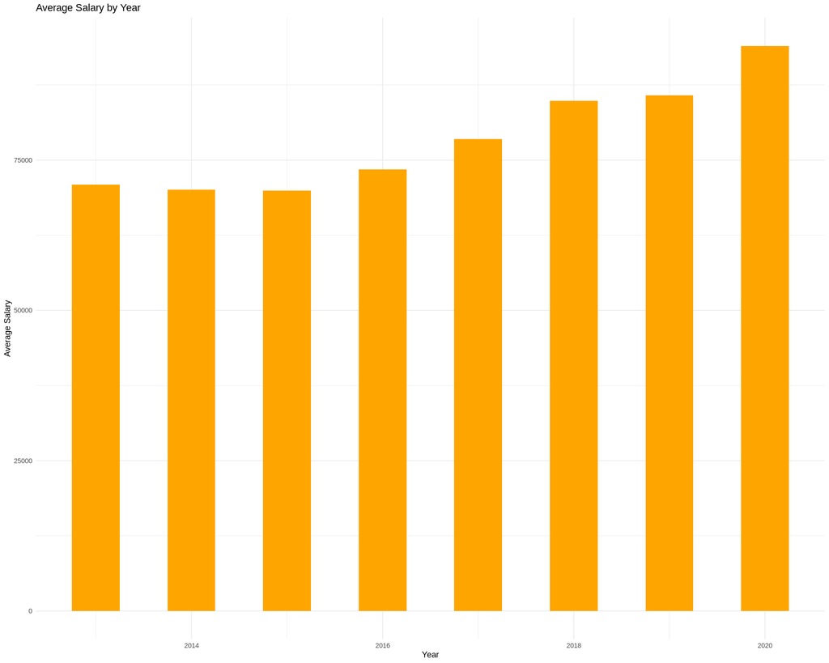

```r
# Create a bar chart
ggplot(result, aes(x = Year, y = Average_Salary)) +
  geom_bar(stat = "identity", fill = "orange", width = 0.5) +
  labs(title = "Average Salary by Year",
       x = "Year",
       y = "Average Salary") +
  theme_minimal()
```

- The plot above describes the average salaries per year for the San Francisco jobs dataset. It can be observed that the average total salaries are more or less same for 2013 to 2015 and then there was a gradual rise in average total salaries after 2016 with 2020 having recorded the highest average salaries.

```r
#Loop 2
C
# Initialize an empty data frame to store the results
lowest_avg_salaries_2020 <- data.frame(Department = character(), Average_Salary = numeric())

# Get unique departments in the dataset
unique_departments <- unique(df2$Department)

# Filter the data for the year 2020
data_2020 <- df2[df2$Year == 2020, ]

# Loop through each unique department
for (department in unique_departments) {
  # Subset the data for the current department
  department_data <- data_2020[data_2020$Department == department, ]

  # Calculate the average salary for the current department
  avg_salary <- mean(department_data$Total.Salary, na.rm = TRUE)

  # Create a new row for the results
  result_row <- data.frame(Department = department, Average_Salary = avg_salary)

  # Append the result row to the lowest_avg_salaries_2020 data frame
  lowest_avg_salaries_2020 <- rbind(lowest_avg_salaries_2020, result_row)
}

# Sort the data frame by average salary in ascending order
lowest_avg_salaries_2020 <- lowest_avg_salaries_2020[order(lowest_avg_salaries_2020$Average_Salary), ]

# Get the top 10 departments with the lowest average salaries
top_10_lowest_avg_salaries <- head(lowest_avg_salaries_2020, 10)

# Print the top 10 departments
print(top_10_lowest_avg_salaries)
```

```
                        Department Average_Salary
103                      Registrar       12851.94
89  Recreation And Park Commission       37482.75
110               Board Of Appeals       47256.64
86                Fine Arts Museum       48506.46
82            Dept Status of Women       50845.50
98        Civil Service Commission       54493.97
87                  Public Library       62286.30
91                    War Memorial       65713.12
80         Human Rights Commission       66451.33
78                     Environment       67934.86
```

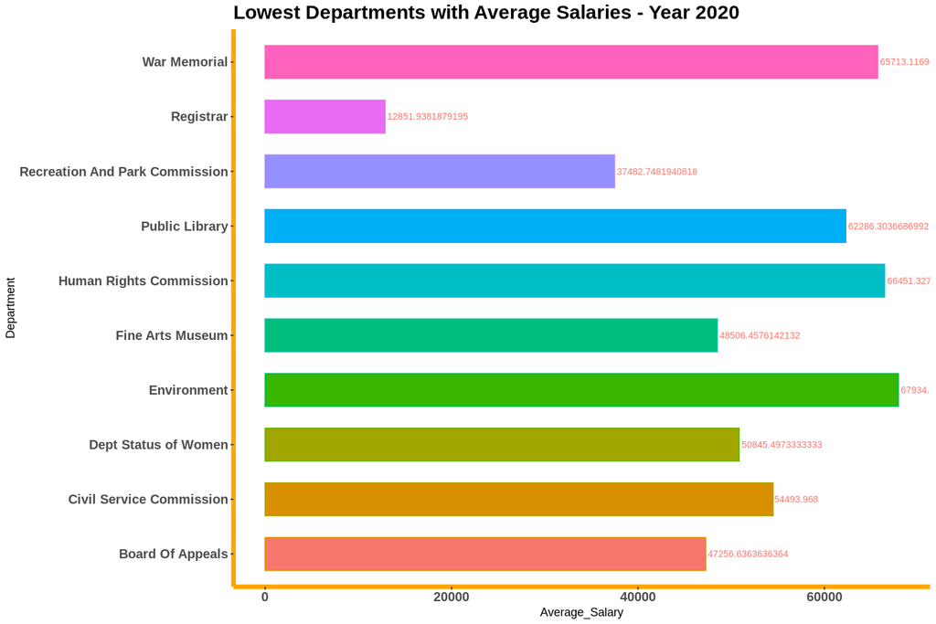

```r
#Plotting graph

ggplot(top_10_lowest_avg_salaries, aes(Department, Average_Salary, color = Department, fill = Department)) +
  geom_bar(position = "stack", width = 0.6, stat = "identity") +
  coord_flip() +
  geom_text(aes(label = Average_Salary, hjust = -0.03, colour = "black"), size = 3) +

  theme(axis.line = element_line(color = "orange", size = 2)) +
  theme(panel.background = element_blank()) +
  scale_x_discrete() +
  xlab("Department") + ylab("Average_Salary") +
  theme(legend.position = "none", axis.text = element_text(size = 12, face = "bold"),
        plot.title = element_text(size = 18, face = "bold")) +
  ggtitle("Lowest Departments with Average Salaries - Year 2020")

#Increasing the plot size
options(
  repr.plot.width = 12,
  repr.plot.height = 8
)
```

- It can be obseved from the plot above that the departments above provide lowest average salaries as per 2020 data. Thus choosing a career option in any of the above departments would result in lower earning potential.

```r
#Loop 3

# Initialize an empty data frame to store the results
top_10_avg_salaries_by_job_family <- data.frame(Job_Family = character(), Average_Salary = numeric())

# Get unique job families in the dataset
unique_job_families <- unique(df2$Job.Family)

# Loop through each unique job family
for (job_family in unique_job_families) {
  # Subset the data for the current job family
  job_family_data <- df2[df2$Job.Family == job_family, ]

  # Calculate the average salary for the current job family
  avg_salary <- mean(job_family_data$Total.Salary, na.rm = TRUE)

  # Create a new row for the results
  result_row <- data.frame(Job_Family = job_family, Average_Salary = avg_salary)

  # Append the result row to the data frame
  top_10_avg_salaries_by_job_family <- rbind(top_10_avg_salaries_by_job_family, result_row)
}

# Sort the data frame by average salary in descending order
top_10_avg_salaries_by_job_family <- top_10_avg_salaries_by_job_family[order(-top_10_avg_salaries_by_job_family$Average_Salary), ]

# Get the top 10 job families with the highest average salaries
top_10_job_families <- head(top_10_avg_salaries_by_job_family, 10)

# Print the top 10 job families
print(top_10_job_families)
```

```
                      Job_Family Average_Salary
54 Administrative & Mgmt (Unrep)       233577.1
59                    Unassigned       144719.2
16                 Fire Services       142302.9
23 Administrative-Labor & Trades       136557.8
22               Police Services       128713.0
42     Construction Project Mgmt       128150.8
40        Administrative-DPW/PUC       126610.1
19              Medical & Dental       125659.9
6                     Management       122645.4
10                 Legal & Court       116021.1
```

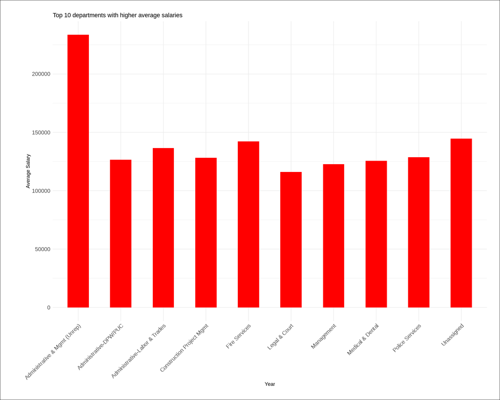

```r
# Create a bar chart
ggplot(top_10_job_families, aes(x = Job_Family, y = Average_Salary)) +
  geom_bar(stat = "identity", fill = "red", width = 0.5) +
  labs(title = "Top 10 departments with higher average salaries",
       x = "Year",
       y = "Average Salary") +
  theme_minimal() +  theme(axis.text.x = element_text(angle = 45, hjust = 1, size = 12),  # Adjust x-axis label size
        axis.text.y = element_text(size = 12),  # Increase y-axis label size
        plot.background = element_rect(fill = "white"),  # Set plot background color
        plot.margin = margin(1, 1, 1, 2, "cm"))  # Adjust plot margins for larger size
```

- It can be observed from the graph above the top 10 job earning job families. A person can choose these departments or can transition to the above departments to increase their earning potentials

# 8) Summary

**Union Influence (List 4):** List 4 analyzes the prevalence of unions within job family types. Notably, job families such as "Nursing" and "Police Services" have a significant union presence, indicating potential job security and collective bargaining advantages for employees in these fields.

**Salary Trends Over the Years**: The visualization of average salaries per year illustrates the evolution of compensation levels in San Francisco from 2013 to 2020. It's evident that average salaries remained relatively stable until 2016, after which they exhibited a gradual increase, with 2020 recording the highest average salaries.

**Departmental Disparities:** The provided data highlights departmental disparities in salaries. Some departments, like "Registrar," "Recreation and Park Commission," and "Board of Appeals," offer notably lower average salaries, while others, like "Administrative & Mgmt (Unrep)" and "Fire Services," provide considerably higher average salaries, showcasing variations in earning potential across departments.

In summary, the content offers comprehensive insights into San Francisco's job market, including employment trends, salary disparities, benefits, and the impact of unions on job security. These findings provide valuable information for individuals seeking employment in the area and shed light on critical aspects of compensation and employment dynamics in the region.

# 9) Recommendations

**Union Membership:** Jobs in job families with significant union representation, such as "Nursing" and "Police Services," may offer better job security and potential bargaining power. Explore opportunities in these fields for added employment stability.

**Salary Trends:** Be aware of salary trends over the years. While recent years have seen salary increases, it's essential to stay informed about changing compensation levels to make informed career decisions.

**Departmental Disparities:** When considering employment in specific departments, factor in salary disparities. Departments like "Administrative & Mgmt (Unrep)" and "Fire Services" tend to offer higher salaries, while others may provide lower earning potential.

**Benefits Assessment:** Examine benefits packages carefully, especially retirement benefits. Jobs with negative retirement benefits, like certain nursing positions, may indicate potential job security concerns after retirement.

Incorporating these considerations into career decisions can help individuals make informed choices and navigate the San Francisco job market effectively.